# Introduction to Malaria Modeling Skills in R & RStudio using ML Algorithms

# Prediction using trained Boosting model

```r
bopred=predict(boModel,newdata = test)

boPredProb <- predict(boModel, newdata = test, type ="prob")*100

# Combine data into a data frame
Ground_truth<- test$Malaria.Test
Predicted <- bopred

resultbo <- data.frame(Ground_truth, Predicted)
resultbo$Correct <- resultbo$Ground_truth == resultbo$Predicted

# Add a column for classification results (correct/incorrect)
resultBoosting<- data.frame(test, bopred, resultbo$Correct)
#head(resultBoosting)
#head(resultbo,987)
```

# Create ROC curve for Boosting model

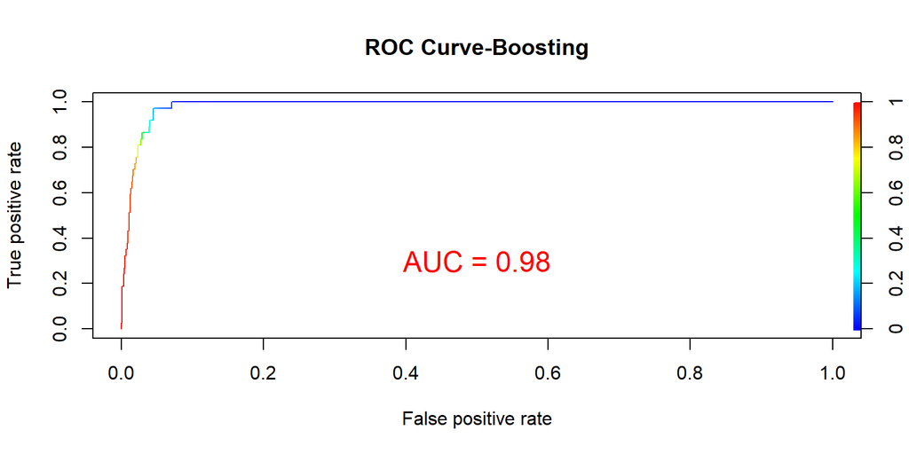

```r
# Make predictions on the test set using type='prob'
predbo <- predict(boModel, newdata = test, type = "prob")
# Create a prediction object needed by ROCR
pred_bo <- prediction(predbo[, "Positive"], test$Malaria.Test)
# Calculate performance measures like ROC curve
perf_bo <- performance(pred_bo, "tpr", "fpr")
# Plot the ROC curve
plot(perf_bo, colorize = TRUE, main = "ROC Curve-Boosting")
# Compute AUC
auc_value <- performance(pred_bo, "auc")@y.values[[1]]
auc_label <- paste("AUC =", round(auc_value, 2))
# Add AUC value as text on the plot
text(0.5, 0.3, auc_label, col = "red", cex = 1.5)  # Adjust position
```

# Checking the performance metrics across models{Tabulate your Results [xtable(measure.score, digits = 3)]}

```r
measure <-round(data.frame(SVM = M1,
                           RF = M2,
                           DT = T2,
                           LR = M3,
                           KNN = M4,
                           NB = M6,
                           LDA = M7,
                           LVQ = M8,
                           Bagging = M9,
                           Boosting = M10), 3)
rownames(measure)=c('Sensitivity', 'Specificity', 'Precision','F1-Score', 'Balanced Accuracy')
measure
```

```
                    SVM    RF    DT    LR   KNN    NB   LDA   LVQ Bagging
Sensitivity       0.784 0.784 0.811 0.973 0.676 0.919 0.919 0.811   0.784
Specificity       0.973 0.979 0.969 0.936 0.980 0.949 0.929 0.691   0.977
Precision         0.527 0.592 0.508 0.371 0.568 0.415 0.337 0.093   0.569
F1-Score          0.630 0.674 0.625 0.537 0.617 0.571 0.493 0.166   0.659
Balanced Accuracy 0.878 0.881 0.890 0.954 0.828 0.934 0.924 0.751   0.880
                  Boosting
Sensitivity          0.838
Specificity          0.972
Precision            0.534
F1-Score             0.653
Balanced Accuracy    0.905
```

# Collect all resamples and compare the models

```r
results <- resamples(list(SVM=SvmModel,
                          RF=RFModel,
                          DT= DTModel,
                          LR=logRegModel,
                          knn=knnModel,
                          NB=NBModel,
                          LDA=LDAModel,
                          LVQ=LVQModel,
                          Bagging=bagModel,
                         Bo=boModel ))
# summarize the distributions of the results
summary(results)
```

```
Call:
summary.resamples(object = results)

Models: SVM, RF, DT, LR, knn, NB, LDA, LVQ, Bagging, Bo
Number of resamples: 50

Accuracy
             Min.   1st Qu.    Median      Mean   3rd Qu.      Max. NA's
SVM     0.9478261 0.9606987 0.9651414 0.9655526 0.9695652 0.9826087    0
RF      0.9565217 0.9737991 0.9739130 0.9760182 0.9825136 0.9956332    0
DT      0.9519651 0.9650655 0.9695652 0.9695610 0.9739130 0.9868996    0
LR      0.9035088 0.9313787 0.9432314 0.9410327 0.9475983 0.9739130    0
knn     0.9217391 0.9432931 0.9519651 0.9517763 0.9606987 0.9781659    0
NB      0.9385965 0.9475983 0.9541571 0.9542926 0.9606987 0.9781659    0
LDA     0.9078947 0.9268559 0.9344978 0.9358859 0.9465683 0.9608696    0
LVQ     0.3130435 0.5579805 0.6484716 0.6273217 0.7019651 0.8209607    0
Bagging 0.9391304 0.9650655 0.9694323 0.9686933 0.9738846 0.9912664    0
Bo      0.9521739 0.9694323 0.9737991 0.9738390 0.9781659 0.9869565    0

Kappa
              Min.    1st Qu.     Median      Mean   3rd Qu.      Max. NA's
SVM     0.32891247 0.53617830 0.61366235 0.5931978 0.6509906 0.7909630    0
RF      0.45083933 0.65303030 0.68640409 0.6984215 0.7505423 0.9389170    0
DT      0.39606809 0.61267170 0.67760006 0.6654964 0.7226112 0.8504246    0
LR      0.35088766 0.48744328 0.52196281 0.5323107 0.5762974 0.7561837    0
knn     0.09383833 0.31831300 0.42191386 0.4160639 0.4933118 0.6945852    0
NB      0.40638086 0.52819369 0.59133624 0.5894496 0.6461538 0.7716849    0
LDA     0.38933333 0.46820809 0.50980876 0.5133620 0.5543964 0.6709062    0
LVQ     0.00000000 0.05635495 0.08241482 0.0874445 0.1085201 0.2020906    0
Bagging 0.39606809 0.56239238 0.63355611 0.6206967 0.6802493 0.8705483    0
Bo      0.45083933 0.65099064 0.69458522 0.6990560 0.7655300 0.8628231    0
```

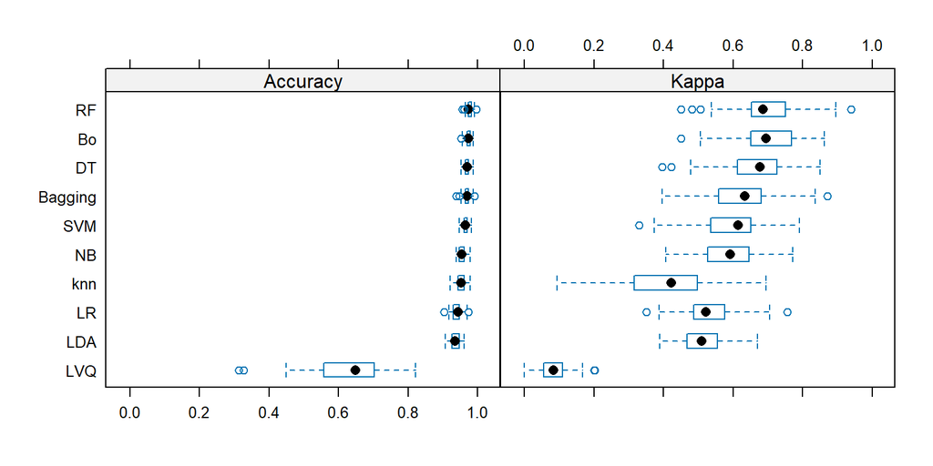

```r
# boxplots of results
bwplot(results)
```

# Box-and-whisker plot of results This type of chart is used to visualize the distribution of data. It shows the following information: * The center of the data (usually the median) * The spread of the data (represented by the box) * The presence of any outliers (data points that fall outside a certain range)

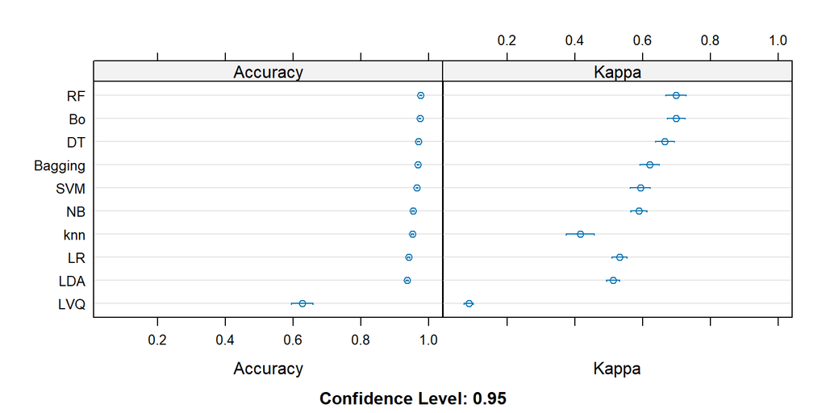

```r
# dot plots of results
 dotplot(results)
```

# —————————————————-

## Resampling Techniques for Handling Data Imbalance

# —————————————————-

● Oversampling ● Undersampling ● Combined Resampling

- Resampling techniques are a common set of strategies used to address data imbalance in machine learning.
- These techniques involve modifying the dataset by either increasing the number of minority class samples (oversampling) or
- reducing the number of majority class samples (undersampling). Here are some key resampling techniques:

# 1. Oversampling:

#● Random Oversampling: In this method, random instances from the minority class are duplicated until a more balanced distribution is achieved. While this can balance the class distribution, it may lead to overfitting.

#● SMOTE (Synthetic Minority Over-sampling Technique): SMOTE generates synthetic instances for the minority class by interpolating between neighboring instances. This approach creates new, realistic data points and helps prevent overfitting compared to random oversampling.

#● ADASYN (Adaptive Synthetic Sampling) * Description: An extension of SMOTE that focuses on generating more synthetic data for minority class examples that are harder to learn. * Advantages: Improves the focus on difficult minority class examples, potentially enhancing model performance. * Disadvantages: Similar to SMOTE, it can introduce noise if not applied carefully.

#● SMOTEN #● SVM-SMOTE #● Random oversampler #● Kmeans-SMOTE

# 2. Undersampling

#● Random Undersampling * Description: Involves randomly removing examples from the majority class to balance the dataset. * Advantages: Reduces the size of the dataset, making the training process faster. * Disadvantages: Can lead to loss of valuable information and underfitting.

#● Tomek Links *Description: Removes examples from the majority class that are close to minority class examples, forming Tomek links.* Advantages: Helps clean the boundary between classes, improving model performance. *Disadvantages: Only removes a small number of majority class examples, may not fully balance the dataset.

#● Random undersampler  
#● NearMiss #● condensed Nearest Neighbour #● Edited Nearest Neaghbour

# 3. Combined Resampling

#● Hybrid Methods *Description: Combines several resampling techniques to leverage their strengths and mitigate their weaknesses.* Advantages: Can provide a more balanced and effective approach. *Disadvantages: More complex to implement and require careful tuning.

## Consideration for Effective Resampling

- Understand Your Data: Know the extent and impact of imbalance.
- Evaluate Multiple Techniques: Different techniques might work better for different datasets.
- Cross-Validation: Use cross-validation to ensure that the model generalizes well.
- Performance Metrics: Focus on metrics like F1-score, precision, recall, and AUC-ROC instead of accuracy.